# Analisis Hubungan Jumlah Rental dan Pendapatan pada Kategori Film di Database Sakila

DARA ADE DIANA SIONEGARA - NIM: M0725062/A

2026-05-24

# Pendahuluan

## Latar Belakang

Database Sakila merupakan database simulasi rental film yang banyak digunakan untuk latihan SQL maupun analisis data. Database ini memiliki berbagai tabel yang saling terhubung seperti data pelanggan, film, kategori film, pembayaran, dan transaksi rental.

Pada laporan ini dilakukan analisis mengenai hubungan antara jumlah rental dan total pendapatan pada setiap kategori film. Insight ini dipilih untuk mengetahui apakah kategori film yang paling sering disewa juga menghasilkan pendapatan paling tinggi.

# Persiapan Library

```r
library(DBI)
library(RMySQL)
library(dplyr)
library(ggplot2)
library(knitr)
```

# Koneksi Database

```r
con <- dbConnect(
  RMySQL::MySQL(),
  dbname = "sakila",
  host = "localhost",
  port = 3306,
  user = "root",
  password = "kindofme"
)
```

# Pengambilan Data

```r
query <- "
SELECT
    c.name AS kategori,
    COUNT(r.rental_id) AS jumlah_rental,
    ROUND(SUM(p.amount),2) AS total_pendapatan
FROM category c
JOIN film_category fc ON c.category_id = fc.category_id
JOIN film f ON fc.film_id = f.film_id
JOIN inventory i ON f.film_id = i.film_id
JOIN rental r ON i.inventory_id = r.inventory_id
JOIN payment p ON r.rental_id = p.rental_id
GROUP BY c.name
ORDER BY jumlah_rental DESC
"

data_film <- dbGetQuery(con, query)

kable(data_film)
```

| kategori | jumlah_rental | total_pendapatan |
| --- | --- | --- |
| Sports | 1179 | 5314.21 |
| Animation | 1166 | 4656.30 |
| Action | 1112 | 4375.85 |
| Sci-Fi | 1101 | 4756.98 |
| Family | 1096 | 4226.07 |
| Drama | 1060 | 4587.39 |
| Documentary | 1050 | 4217.52 |
| Foreign | 1033 | 4270.67 |
| Games | 969 | 4281.33 |
| Children | 945 | 3655.55 |
| Comedy | 941 | 4383.58 |
| New | 940 | 4351.62 |
| Classics | 939 | 3639.59 |
| Horror | 846 | 3722.54 |
| Travel | 837 | 3549.64 |
| Music | 830 | 3417.72 |

# Visualisasi Data

## 1. Jumlah Rental Berdasarkan Kategori Film

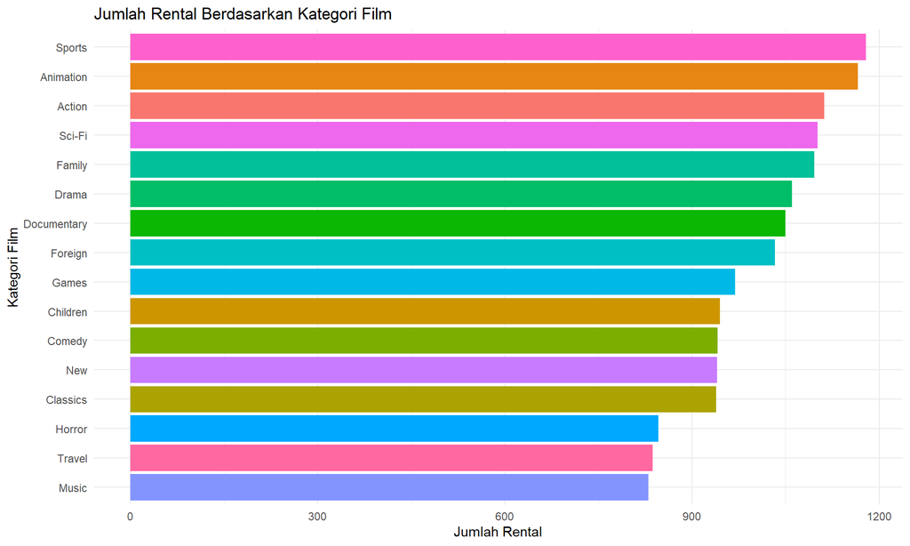

```r
ggplot(data_film, aes(x = reorder(kategori, jumlah_rental),
                      y = jumlah_rental,
                      fill = kategori)) +
  geom_bar(stat = "identity") +
  coord_flip() +
  labs(
    title = "Jumlah Rental Berdasarkan Kategori Film",
    x = "Kategori Film",
    y = "Jumlah Rental"
  ) +
  theme_minimal() +
  theme(legend.position = "none")
```

### Interpretasi

Dari grafik terlihat bahwa ada beberapa kategori yang jauh lebih sering disewa dibanding kategori lainnya. Ini menunjukkan bahwa pelanggan memiliki minat terhadap genre film tertentu.

Kategori dengan jumlah rental tinggi bisa dianggap sebagai kategori yang paling diminati pelanggan.

## 2. Total Pendapatan Berdasarkan Kategori Film

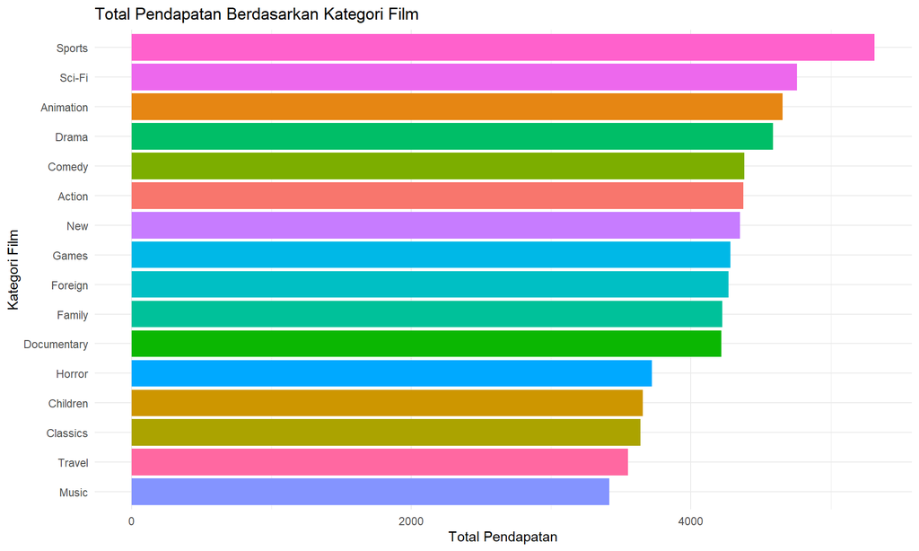

```r
ggplot(data_film, aes(x = reorder(kategori, total_pendapatan),
                      y = total_pendapatan,
                      fill = kategori)) +
  geom_bar(stat = "identity") +
  coord_flip() +
  labs(
    title = "Total Pendapatan Berdasarkan Kategori Film",
    x = "Kategori Film",
    y = "Total Pendapatan"
  ) +
  theme_minimal() +
  theme(legend.position = "none")
```

### Interpretasi

Kategori yang sering disewa ternyata cenderung menghasilkan pendapatan lebih tinggi. Namun terdapat beberapa kategori yang jumlah rentalnya tidak terlalu tinggi tetapi tetap memberikan pendapatan yang cukup besar.

Hal ini menunjukkan bahwa banyaknya transaksi memang berpengaruh terhadap pendapatan, tetapi tidak sepenuhnya menentukan.

## 3. Scatter Plot Hubungan Rental dan Pendapatan

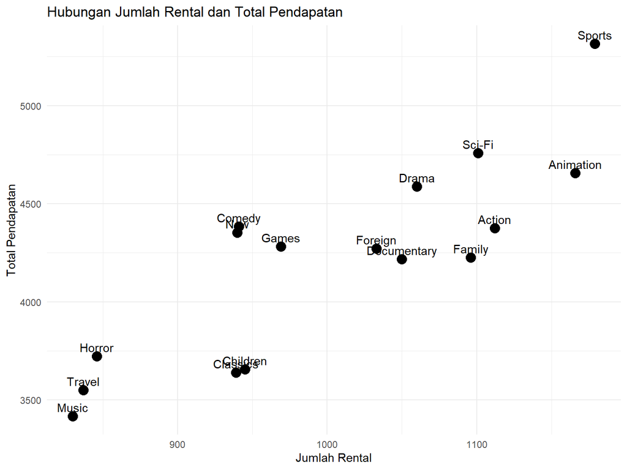

```r
ggplot(data_film, aes(x = jumlah_rental,
                      y = total_pendapatan,
                      label = kategori)) +
  geom_point(size = 4) +
  geom_text(vjust = -0.5) +
  labs(
    title = "Hubungan Jumlah Rental dan Total Pendapatan",
    x = "Jumlah Rental",
    y = "Total Pendapatan"
  ) +
  theme_minimal()
```

### Interpretasi

Scatter plot menunjukkan pola hubungan positif antara jumlah rental dan total pendapatan. Semakin tinggi jumlah rental suatu kategori, maka total pendapatannya juga cenderung meningkat.

Titik yang berada paling jauh bisa dikatakan sebagai kategori yang lebih unggul dibanding kategori lain.

# Analisis Statistik

```r
mean_rental <- mean(data_film$jumlah_rental)
mean_pendapatan <- mean(data_film$total_pendapatan)

korelasi <- cor(data_film$jumlah_rental,
                data_film$total_pendapatan)

mean_rental
```

```
## [1] 1002.75
```

```r
mean_pendapatan
```

```
## [1] 4212.91
```

```r
korelasi
```

```
## [1] 0.8486797
```

Persamaan mean:
$$\bar{x} = \frac{\sum x}{n}$$
Keterangan: - $\bar{x}$ = rata-rata - $x$ = jumlah rental - $n$ = banyak kategori film

Persamaan korelasi Pearson:
$$r = \frac{n\sum xy - (\sum x)(\sum y)}
{\sqrt{[n\sum x^2 - (\sum x)^2][n\sum y^2 - (\sum y)^2]}}$$
Keterangan: - $r$ = koefisien korelasi Pearson - $n$ = jumlah data - $x$ = variabel jumlah rental - $y$ = variabel total pendapatan - $\sum xy$ = jumlah hasil perkalian antara variabel $x$ dan $y$ - $\sum x$ = jumlah seluruh nilai variabel $x$ - $\sum y$ = jumlah seluruh nilai variabel $y$ - $\sum x^2$ = jumlah kuadrat variabel $x$ - $\sum y^2$ = jumlah kuadrat variabel $y$

### Interpretasi Statistik

Koefisien korelasi Pearson digunakan untuk mengukur kekuatan hubungan linear antara dua variabel. Nilai korelasi berada pada rentang -1 hingga 1. Pada analisis kali ini, nilai korelasi digunakan untuk melihat hubungan antara jumlah rental dan total pendapatan.

Jika nilai korelasi mendekati 1, berarti hubungan keduanya kuat dan positif. Artinya kategori yang sering disewa biasanya juga menghasilkan pendapatan yang tinggi.

# Kesimpulan

Berdasarkan analisis yang telah dilakukan dapat disimpulkan bahwa kategori film dengan jumlah rental tinggi cenderung menghasilkan pendapatan yang lebih besar. Selain itu terdapat hubungan positif antara jumlah rental dan total pendapatan.

Visualisasi data membantu melihat pola hubungan antar variabel dengan lebih jelas sehingga insight lebih mudah dipahami.

# Menutup Koneksi

```r
dbDisconnect(con)
```

```
## [1] TRUE
```